# EDA - STUDENT BEHAVIOUR

Urszula Zastawna

2023-11-30

## Pakiety, których będę używać

```r
library(dplyr)
library(ggplot2)
library(tidyverse)
library(psych)
library(mice)
library(corrplot)
```

## **OPIS ZESTAWU DANYCH**

Zbiór danych”Student Behaviour” zawiera rożne informacje dotyczące studentów zebrane za pomocą formularza Google.

### Zbiór zawiera następujące kolumny:

**Certification.Course** (Certyfikat) - zmienna typu character: wskazuje, czy student ukończył dowolny kurs certyfikacyjny, czy nie

**Gender** (Płeć) - zmienna typu character

**Department** (Kierunek) - zmienna typu character: kierunek studiów, na którym studiował student. Możliwe opcje:

- BCA
- Commerce
- B.com ISM
- B.com Accounting and Finance

**Height.CM.** (Wzrost) - zmienna liczbowa: wzrost Studenta w centymetrach

**Weight.KG.** (Waga) - zmienna liczbowa: waga Studenta w kilogramach

**X10th.Mark** (Ocena10) - zmienna liczbowa: Ocena końcowa Studenta w 10 klasie

**X12th.Mark** (Ocena12) - zmienna liczbowa: Ocena końcowa Studenta w 12 klasie

**college.mark** (OcenaUczelnia) - zmienna liczbowa: Ocena końcowa Studenta na uczelni

**hobbies** (Hobby) - zmienna typu character: Hobby Studenta; opcje:

- Sports (Sport)
- Cinema (Kino)
- Video Games (Gry komputerowe)
- Reading books (Czytanie książek)

**daily.studing.time** (CzasNauki) - zmienna typu character: Ilość czasu spędzona na nauce w ciągu dnia; do wyboru przedziały:

**prefer.to.study.in** (PreferowanaPoraNauki): do wybory opcje:  
- Anytime (Obojętnie)  
- Morning (Rano)  
- Night (Wieczorem/W nocy)

**salary.expectation** (OczekiwaneWynagrodzenie) - zmienna liczbowa: Oczekiwana wartość otrzymywanego wynagrodzenia

**Do.you.like.your.degree** (CzyLubiszSwojDyplom) - zmienna typu character

**willingness.to.pursue.a.career.based.on.their.degree** (DalszaKariera) - zmienna typu character: Chęć, gotowość studenta do kontynuowania kariery zawodowej związanej z posiadanym wykształceniem; wyrażona w procentach; do wybory opcje:

- 0%
- 25%
- 50%
- 75%
- 100%

**social.medai…video** (SocialMedia): Czas spędzony przez Studenta dziennie na social mediach lub oglądaniu video; do wyboru przedziały:

**Travelling.Time** (CzasDojazdu) - zmienna typu character: Czas spędzony przez Studenta dziennie na dojazd do placówki edukacyjnej; do wybory przedziały:

**Stress.Level** (Stres) - zmienna typu character: Poziom stresu Studenta; do wyboru opcje:

- fabulous
- Good
- Bad
- Awful

**Financial.Status** (StatusFinansowy) - zmienna typu character: Sytuacja finansowa, ekonomiczna studenta; do wyboru opcje:

- Fabulous
- good
- Bad
- Awful

**part.time.job** (Praca) - zmienna typu character: Informacja, czy student pracuje w niepełnym wymiarze godzin.

## **WCZYTANIE DANYCH I WSTĘPNY OGLĄD**

```r
dane <- read.csv(file = "C:/Users/Asus/Desktop/R/Student_Behaviour.csv", sep = ",")
```

Badam strukturę danych - ilość obserwacji, ilość zmiennych i typy zmiennych:

```r
str(dane)
```

```
## 'data.frame':    235 obs. of  19 variables:
##  $ Certification.Course                                : chr  "No" "No" "Yes" "Yes" ...
##  $ Gender                                              : chr  "Male" "Female" "Male" "Female" ...
##  $ Department                                          : chr  "BCA" "BCA" "BCA" "BCA" ...
##  $ Height.CM.                                          : num  100 90 159 147 170 139 165 152 190 150 ...
##  $ Weight.KG.                                          : num  58 40 78 20 54 33 50 43 85 84 ...
##  $ X10th.Mark                                          : num  79 70 69.5 70 40 90 70 61.6 88.2 60 ...
##  $ X12th.Mark                                          : num  65 80 61 59 65 ...
##  $ college.mark                                        : num  80 70 55 58 30 70 3 75 60 70 ...
##  $ hobbies                                             : chr  "Video Games" "Cinema" "Cinema" "Reading books" ...
##  $ daily.studing.time                                  : chr  "0 - 30 minute" "30 - 60 minute" "1 - 2 Hour" "1 - 2 Hour" ...
##  $ prefer.to.study.in                                  : chr  "Morning" "Morning" "Anytime" "Anytime" ...
##  $ salary.expectation                                  : int  40000 15000 13000 1500000 50000 20000 15000 25000 20000 20000 ...
##  $ Do.you.like.your.degree.                            : chr  "No" "Yes" "Yes" "No" ...
##  $ willingness.to.pursue.a.career.based.on.their.degree: chr  "50%" "75%" "50%" "50%" ...
##  $ social.medai...video                                : chr  "1.30 - 2 hour" "1 - 1.30 hour" "More than 2 hour" "1.30 - 2 hour" ...
##  $ Travelling.Time                                     : chr  "30 - 60 minutes" "0 - 30 minutes" "30 - 60 minutes" "0 - 30 minutes" ...
##  $ Stress.Level                                        : chr  "Bad" "Bad" "Awful" "Bad" ...
##  $ Financial.Status                                    : chr  "Bad" "Bad" "Bad" "good" ...
##  $ part.time.job                                       : chr  "No" "No" "No" "No" ...
```

Oglądam dane: 5 pierwszych i 5 ostatnich.

```r
head(dane, 5)
```

```
##   Certification.Course Gender Department Height.CM. Weight.KG. X10th.Mark
## 1                   No   Male        BCA        100         58       79.0
## 2                   No Female        BCA         90         40       70.0
## 3                  Yes   Male        BCA        159         78       69.5
## 4                  Yes Female        BCA        147         20       70.0
## 5                   No   Male        BCA        170         54       40.0
##   X12th.Mark college.mark       hobbies daily.studing.time prefer.to.study.in
## 1         65           80   Video Games      0 - 30 minute            Morning
## 2         80           70        Cinema     30 - 60 minute            Morning
## 3         61           55        Cinema         1 - 2 Hour            Anytime
## 4         59           58 Reading books         1 - 2 Hour            Anytime
## 5         65           30   Video Games     30 - 60 minute            Morning
##   salary.expectation Do.you.like.your.degree.
## 1              40000                       No
## 2              15000                      Yes
## 3              13000                      Yes
## 4            1500000                       No
## 5              50000                      Yes
##   willingness.to.pursue.a.career.based.on.their.degree social.medai...video
## 1                                                  50%        1.30 - 2 hour
## 2                                                  75%        1 - 1.30 hour
## 3                                                  50%     More than 2 hour
## 4                                                  50%        1.30 - 2 hour
## 5                                                  25%        1.30 - 2 hour
##   Travelling.Time Stress.Level Financial.Status part.time.job
## 1 30 - 60 minutes          Bad              Bad            No
## 2  0 - 30 minutes          Bad              Bad            No
## 3 30 - 60 minutes        Awful              Bad            No
## 4  0 - 30 minutes          Bad             good            No
## 5 30 - 60 minutes         Good             good            No
```

```r
tail(dane, 5)
```

```
##     Certification.Course Gender Department Height.CM. Weight.KG. X10th.Mark
## 231                  Yes   Male  B.com ISM        170         76         72
## 232                  Yes   Male  B.com ISM        172         52         72
## 233                  Yes Female        BCA        139         33         90
## 234                  Yes Female   Commerce        153         58         85
## 235                   No Female  B.com ISM        155         39         45
##     X12th.Mark college.mark     hobbies daily.studing.time prefer.to.study.in
## 231         67           65 Video Games     30 - 60 minute            Morning
## 232         70           76      Cinema         2 - 3 hour            Anytime
## 233         75           70      Cinema     30 - 60 minute              Night
## 234         74           75      Cinema      0 - 30 minute            Anytime
## 235         45           50      Sports         3 - 4 hour              Night
##     salary.expectation Do.you.like.your.degree.
## 231               7000                      Yes
## 232              25000                      Yes
## 233              20000                      Yes
## 234              20000                      Yes
## 235                 10                       No
##     willingness.to.pursue.a.career.based.on.their.degree social.medai...video
## 231                                                  50%     More than 2 hour
## 232                                                  75%       30 - 60 Minute
## 233                                                  50%       30 - 60 Minute
## 234                                                  75%     More than 2 hour
## 235                                                  75%       30 - 60 Minute
##     Travelling.Time Stress.Level Financial.Status part.time.job
## 231 30 - 60 minutes          Bad              Bad            No
## 232 30 - 60 minutes         Good             good            No
## 233   2.30 - 3 hour          Bad             good            No
## 234   2.30 - 3 hour        Awful             good            No
## 235   2.30 - 3 hour     fabulous             good            No
```

Zmieniam nazwy na polskie - krótsze i łatwiejsze do zrozumienia.

```r
nazwy <- c("Certyfikat", "Plec", "Kierunek", "Wzrost", "Waga", "Ocena10", "Ocena12",
           "OcenaUczelnia", "Hobby", "CzasNauki", "PreferowanaPoraNauki",
           "OczekiwaneWynagrodzenie", "CzyLubiszSwojDyplom", "DalszaKariera",
           "SocialMedia", "CzasDojazdu", "Stres", "StatusFinansowy", "Praca")
names(dane) <- nazwy
```

Sprawdzam, czy są braki danych, za pomocą funkcji md.pattern() z pakietu mice

```
##  /\     /\
## {  `---'  }
## {  O   O  }
## ==>  V <==  No need for mice. This data set is completely observed.
##  \  \|/  /
##   `-----'
```

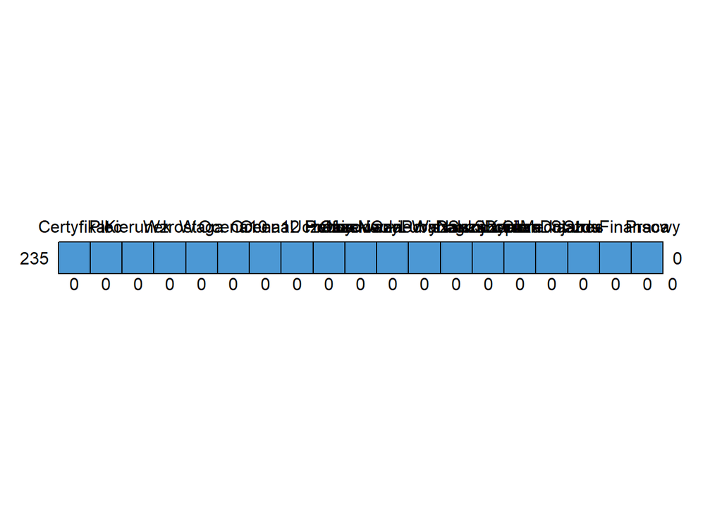

```
##     Certyfikat Plec Kierunek Wzrost Waga Ocena10 Ocena12 OcenaUczelnia Hobby
## 235          1    1        1      1    1       1       1             1     1
##              0    0        0      0    0       0       0             0     0
##     CzasNauki PreferowanaPoraNauki OczekiwaneWynagrodzenie CzyLubiszSwojDyplom
## 235         1                    1                       1                   1
##             0                    0                       0                   0
##     DalszaKariera SocialMedia CzasDojazdu Stres StatusFinansowy Praca
## 235             1           1           1     1               1     1 0
##                 0           0           0     0               0     0 0
```

```r
md.pattern(dane)
```

Funkcja potwierdziła, że nie mamy braków danych.

## **ANALIZA ZMIENNYCH**

### 1. Zmienna *‘Certyfikat’*:

Zmienna ta wskazuje, czy student ukończył dowolny kurs certyfikacyjny, czy nie. Jest to zmienna typu character, która przyjmuje wartości ‘Yes’ lub ‘No’. Zmieniam typ na *factor*, a następnie za pomocą funkcji *table()* patrzę ile jest poszczególnych wartości

```r
dane$Certyfikat <- as.factor(dane$Certyfikat)

table(dane$Certyfikat)
```

```
##
##  No Yes
##  83 152
```

Widzę, że 152 osoby z 235 ukończyły kurs certyfikacyjny, co daje prawie 2/3 badanych

### 2. Zmienna *‘Plec’*:

Jest to zmienna typu character, przyjmująca wartości ‘Female’ lub ‘Male’. Zmieniam typ na *factor* i za pomocą funkcji *table()* patrzę ile jest poszczególnych wartości

```r
dane$Plec <- as.factor(dane$Plec)

table(dane$Plec)
```

```
##
## Female   Male
##     79    156
```

Zdecydowana większość badanych (prawie 2/3) to mężczyźni.

### 3. Zmienna *‘Kierunek’*:

Zmienna opisująca kierunek studiów, na którym studiował student.  
Możliwe wartości:

- BCA - Bachelor of Computer Application (Licencjat z aplikacji komputerowych);
- Commerce (Handel)
- B.com ISM - Bachelor of Commerce in Information System and Management (Licencjat w zakresie systemów informatycznych i zarządzania)
- B.com Accounting and Finance - Bachelor of Commerce in Accounting and Finance (Licencjat w zakresie rachunkowości i finansów)

**B.com to tytuł licencjata w dziedzinie biznesu, zarządzania, ekonomii lub rachunkowości, przyznawany w niektórych krajach

Jest to zmienna typu *character*, ale zmieniam typ na *factor* w celu ułatwienia dalszych analiz. Za pomocą funkcji *table()* sprawdzam ile studentów studiuje/studiowało na poszczególnych kierunkach. Dodatkowo przedstawiam te dane na wykresie kolumnowym

```r
dane$Kierunek <- as.factor(dane$Kierunek)

table(dane$Kierunek)
```

```
##
## B.com Accounting and Finance                      B.com ISM
##                            15                            28
##                           BCA                      Commerce
##                           132                            60
```

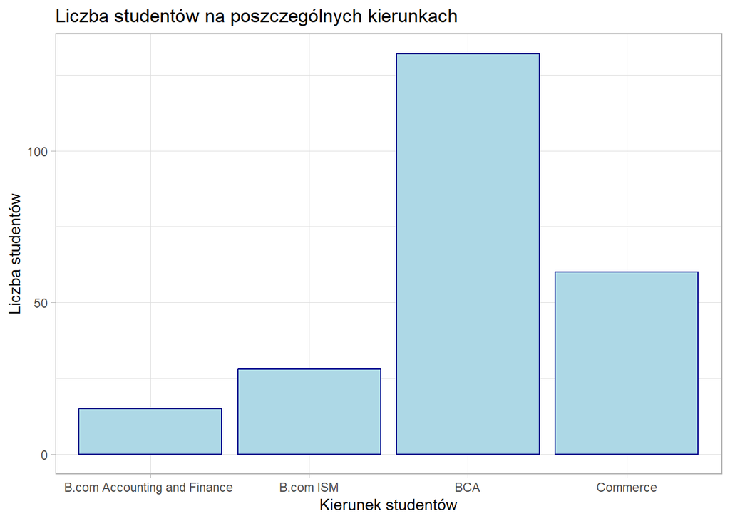

```r
dane %>%
  ggplot() +
  geom_bar(aes(x = Kierunek),
           position = "dodge2",
           color = "darkblue", fill = "lightblue") +
theme_light() +
  labs(title = "Liczba studentów na poszczególnych kierunkach",
       x = "Kierunek studentów",
       y = "Liczba studentów")
```

### 4. Zmienna *‘Wzrost’*:

Zmienna opisująca wzrost studenta w centymetrach. Jest to zmienna liczbowa. Wyświetlam jej podstawowe statystyki opisowe i generuję wykres pudełkowy z dodatkowym nałożeniam wykresu punktowego.

```r
summary(dane$Wzrost)
```

```
##    Min. 1st Qu.  Median    Mean 3rd Qu.    Max.
##     4.5   152.0   160.0   157.4   170.0   192.0
```

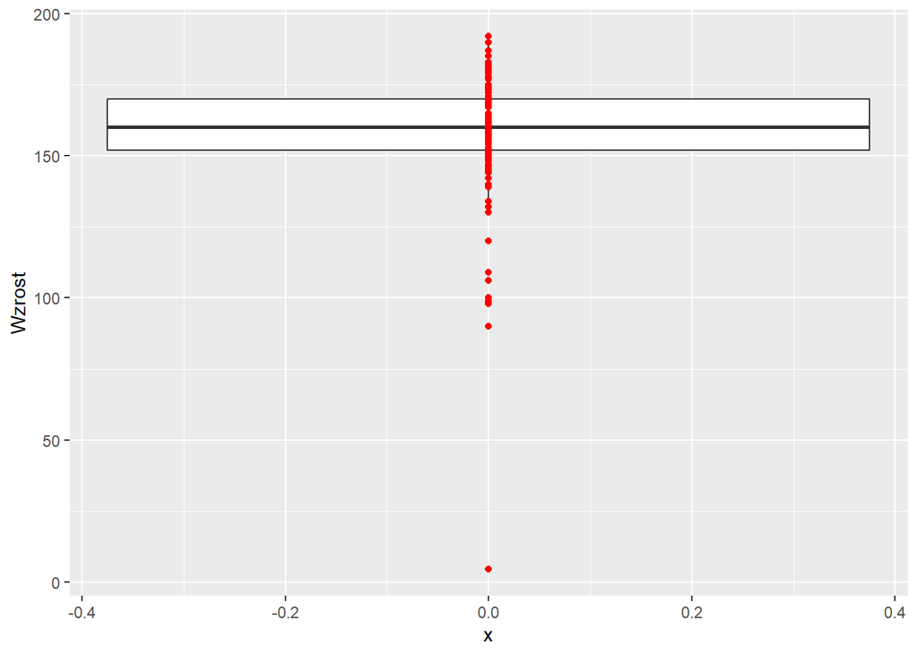

```r
dane %>%
  ggplot() +
  geom_boxplot(aes(y = Wzrost))+
  geom_point(aes(x=0, y=Wzrost), color="red")
```

Widać, że mamy jedną dziwną, zastanawiającą wartość odstającą: 4 cm. Raczej nie jest możliwe, aby ktoś miał taki wzrost. Podejrzewam, iż jeśli dane pochodzą z formularza google, wartość ta może wynikać, albo z nieuważnego przeczytania pytania, albo omyłkowego wpisania błędnej wartości, albo z niechęci podania prawdziwej wartości.

### 5. Zmienna *‘Waga’*:

Zmienna opisująca wagę studenta w kilogramach. Jest to zmienna liczbowa. Wyświetlam jej podstawowe statystyki opisowe i generuję wykres pudełkowy z dodatkowym nałożeniam wykresu punktowego.

```r
summary(dane$Waga)
```

```
##    Min. 1st Qu.  Median    Mean 3rd Qu.    Max.
##    20.0    50.0    60.0    60.8    70.0   106.0
```

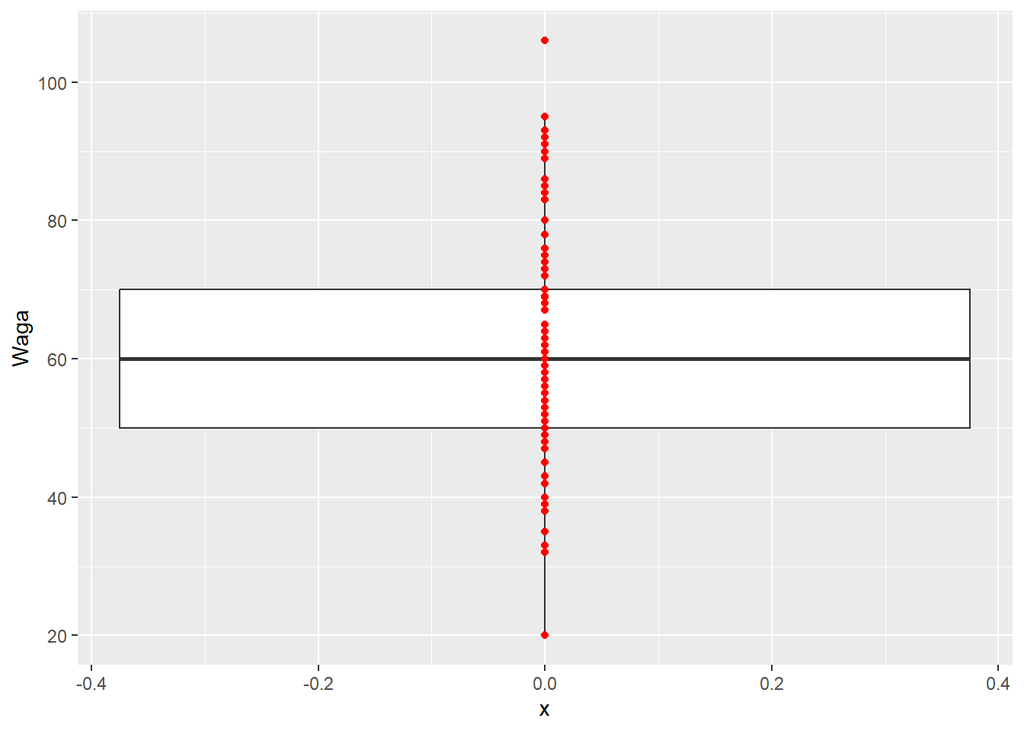

```r
dane %>%
  ggplot() +
  geom_boxplot(aes(y = Waga))+
  geom_point(aes(x=0, y=Waga), color="red")
```

### 6. Zmienna *‘Ocena10’*:

Zmienna opisująca ocenę końcową studenta w 10 klasie (w skali 1-100, czyli może są to procenty). Jest to zmienna liczbowa. Wyświetlam jej podstawowe statystyki opisowe i generuję wykres pudełkowy z dodatkowym nałożeniam wykresu punktowego.

```r
summary(dane$Ocena10)
```

```
##    Min. 1st Qu.  Median    Mean 3rd Qu.    Max.
##    7.40   70.00   80.00   76.84   86.25   98.00
```

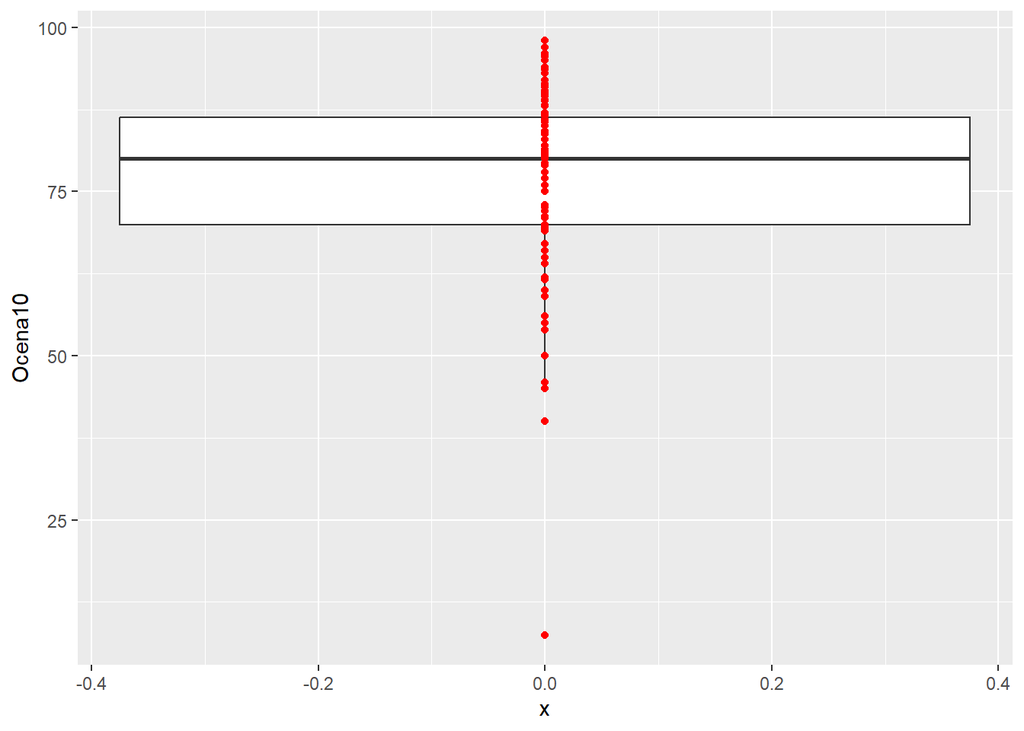

```r
dane %>%
  ggplot() +
  geom_boxplot(aes(y = Ocena10))+
  geom_point(aes(x=0, y=Ocena10), color="red")
```

### 7. Zmienna *‘Ocena12’*:

Zmienna opisująca ocenę końcową studenta w 12 klasie (w skali 1-100, czyli może są to procenty). Jest to zmienna liczbowa. Wyświetlam jej podstawowe statystyki opisowe i generuję wykres pudełkowy z dodatkowym nałożeniam wykresu punktowego.

```r
summary(dane$Ocena12)
```

```
##    Min. 1st Qu.  Median    Mean 3rd Qu.    Max.
##   45.00   60.00   69.00   68.78   76.00   94.00
```

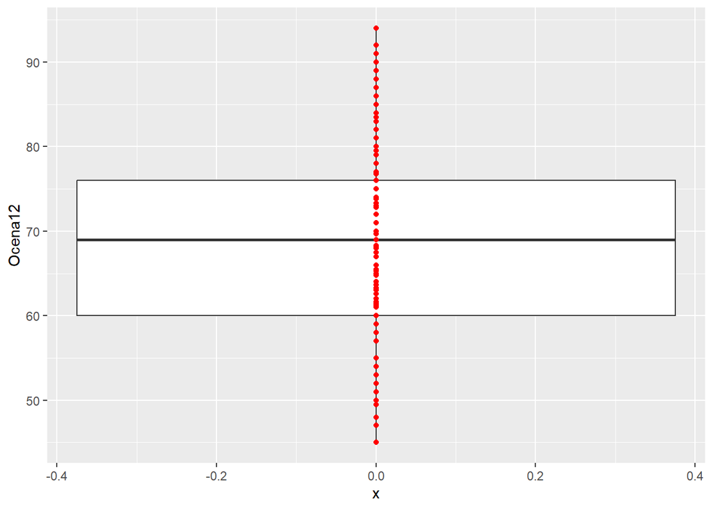

```r
dane %>%
  ggplot() +
  geom_boxplot(aes(y = Ocena12))+
  geom_point(aes(x=0, y=Ocena12), color="red")
```

### 8. Zmienna *‘OcenaUczelnia’*:

Zmienna opisująca ocenę końcową studenta na uczelni (w skali 1-100, czyli może są to procenty). Jest to zmienna liczbowa. Wyświetlam jej podstawowe statystyki opisowe i generuję wykres pudełkowy z dodatkowym nałożeniam wykresu punktowego.

```r
summary(dane$OcenaUczelnia)
```

```
##    Min. 1st Qu.  Median    Mean 3rd Qu.    Max.
##    1.00   60.00   70.00   70.66   80.00  100.00
```

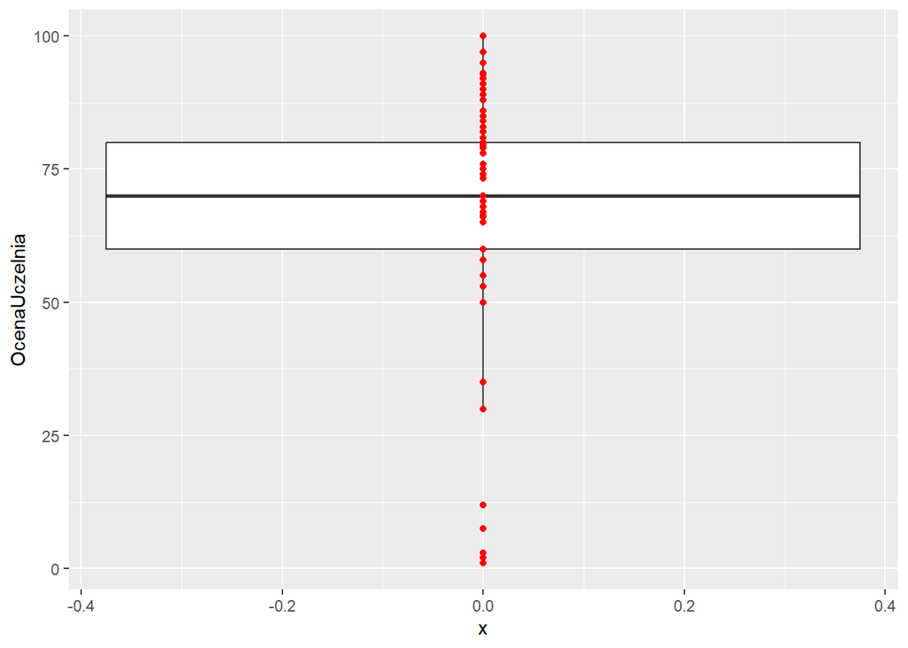

```r
dane %>%
  ggplot() +
  geom_boxplot(aes(y = OcenaUczelnia))+
  geom_point(aes(x=0, y=OcenaUczelnia), color="red")
```

### 9. Zmienna *‘Hobby’*:

Zmienna opisuje jakie są zainteresowania (hobby) studenta.  
Możliwe wartości:

- Sports (Sport)
- Cinema (Kino)
- Video Games (Gry komputerowe)
- Reading books (Czytanie książek)

Jest to zmienna typu *character*, dlatego zmieniam na typ *factor* w celu ułatwienia dalszych analiz. Za pomocą funkcji *table()* sprawdzam ile studentów ma poszczególne zainteresowania. Dodatkowo przedstawiam te dane na wykresie kolumnowym

```r
dane$Hobby <- as.factor(dane$Hobby)

table(dane$Hobby)
```

```
##
##        Cinema Reading books        Sports   Video Games
##            78            36            85            36
```

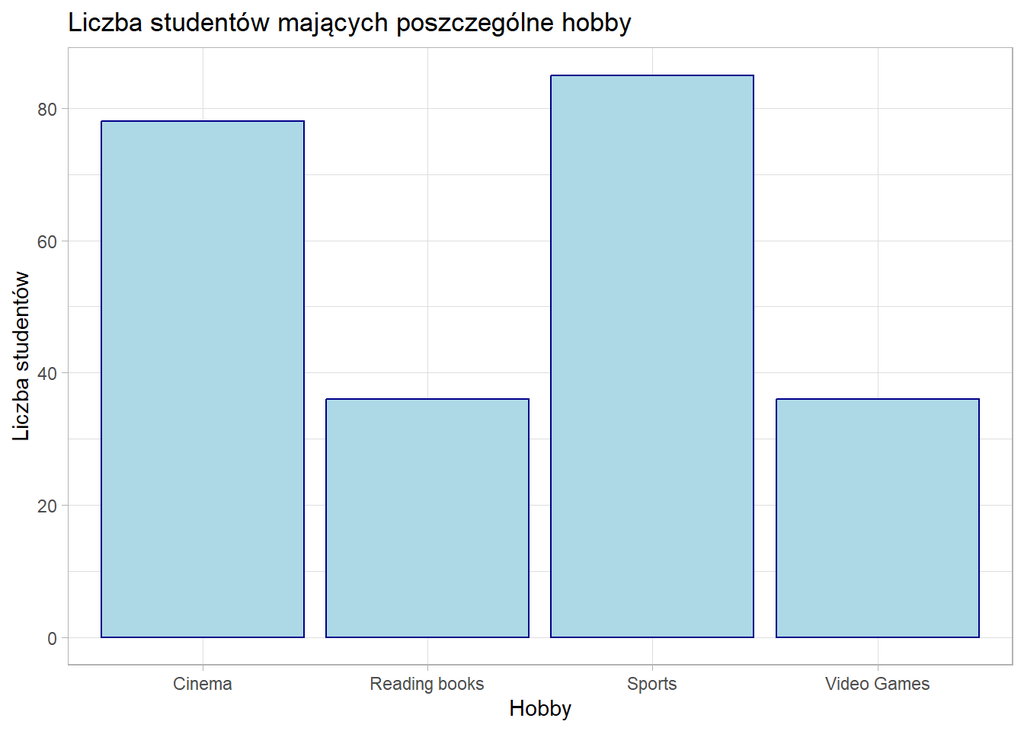

```r
dane %>%
  ggplot() +
  geom_bar(aes(x = Hobby),
           position="dodge2",
           color = "darkblue", fill = "lightblue") +
  theme_light() +
  labs(title = "Liczba studentów mających poszczególne hobby",
       x = "Hobby",
       y="Liczba studentów")
```

### 10. Zmienna *‘CzasNauki’*:

Zmienna opisująca ilość czasu spędzoną na nauce w ciągu dnia.  
Możliwe przedziały:

Jest to zmienna typu *character*, ale ponownie zamieniam ją na *factor*. Powinna to być zmienna kategoryczna, bo mamy kolejne poziomy czasu spędzonego na nauce, dlatego nadaję kolejność poszczególnym kategoriom, zmieniając od razu nazwy przedziałów na krótsze, logiczne, poprawne gramatycznie, ujednolicone (Pierwotnie jedne wartości były z wielkiej, inne z małej litery, w dodatku np. do wiecej niż jednej godziny nie było liczby mnogiej hours).  
Za pomocą funkcji *table()* sprawdzam ile studentów spędza określony czas na nauce. Dodatkowo przedstawiam te dane na wykresie kolumnowym

```r
dane$CzasNauki <- as.factor(dane$CzasNauki)

dane$CzasNauki <- factor(dane$CzasNauki, levels=c("0 - 30 minute", "30 - 60 minute", "1 - 2 Hour", "2 - 3 hour", "3 - 4 hour", "More Than 4 hour"), labels = c("0-0.5h", "0.5-1h", "1-2h", "2-3h", "3-4h", ">4h"))

table(dane$CzasNauki)
```

```
##
## 0-0.5h 0.5-1h   1-2h   2-3h   3-4h    >4h
##     46     81     61     24     15      8
```

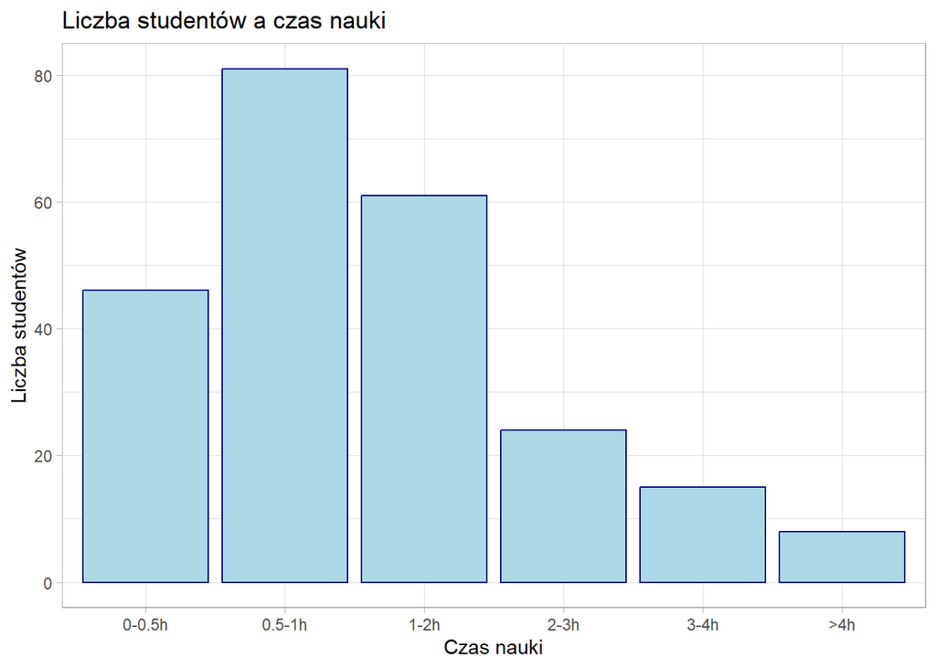

```r
dane %>%
  ggplot() +
  geom_bar(aes(x = CzasNauki),
           position="dodge2",
           color = "darkblue", fill = "lightblue") +
  theme_light() +
  labs(title = "Liczba studentów a czas nauki",
       x = "Czas nauki",
       y="Liczba studentów")
```

### 11. Zmienna *‘PreferowanaPoraNauki’*:

Zmienna opisuje, jaką porę dnia studenci preferują do nauki.  
Możliwe są opcje:

- Anytime (Obojętnie)
- Morning (Rano)
- Night (Wieczorem/W nocy)

Ponownie jest to zmienna typu *character*, którą zamieniam na typ *factor*. Za pomocą funkcji *table()* sprawdzam ile studentów preferuje poszczególne pory dnia.

```r
dane$PreferowanaPoraNauki <- as.factor(dane$PreferowanaPoraNauki)

table(dane$PreferowanaPoraNauki)
```

```
##
## Anytime Morning   Night
##     111      77      47
```

### 12. Zmienna *‘OczekiwaneWynagrodzenie’*:

Zmienna opisująca oczekiwaną wartość otrzymywanego w przyszłości wynagrodzenia. Jest to zmienna liczbowa. Wyświetlam jej podstawowe statystyki opisowe, a także, ponieważ mamy do czynienia z dużymi wartościami, zmieniam je tak, aby były wyświetlane w tysiącach. Generuję wykres pudełkowy z dodatkowym nałożeniam wykresu punktowego.

```r
summary(dane$OczekiwaneWynagrodzenie)
```

```
##    Min. 1st Qu.  Median    Mean 3rd Qu.    Max.
##       0   15000   20000   32482   25000 1500000
```

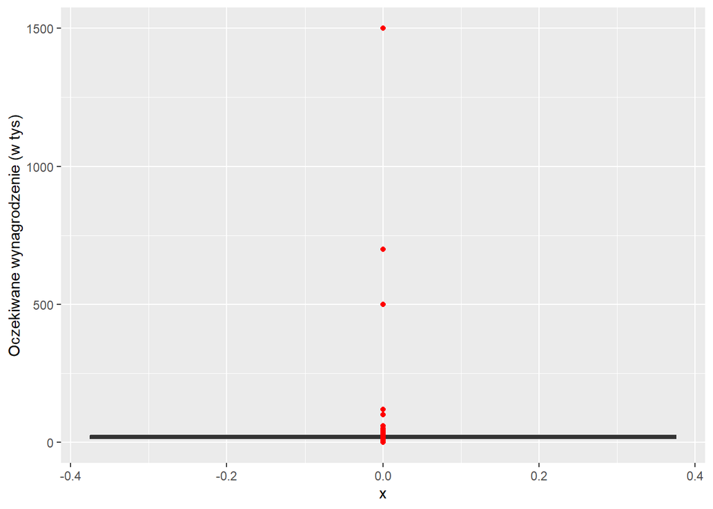

```r
dane1 <- dane %>%
  mutate(OczekiwaneWynagrodzenie = OczekiwaneWynagrodzenie/1000)

dane1 %>%
  ggplot() +
  geom_boxplot(aes(y = OczekiwaneWynagrodzenie))+
  geom_point(aes(x=0, y=OczekiwaneWynagrodzenie), color="red")+
  labs(y="Oczekiwane wynagrodzenie (w tys)")
```

Widać, że wykres jest średnio czytelny. Dzieje się tak dlatego, że zdecydowana większość wartości jest w okolicach 20000, jednak jeden student sobie zamarzył 1500000, co stanowi wartość odstającą i powoduje konieczność dużego zakresu skali. Generuję wykres jeszcze raz, bez tej wartości

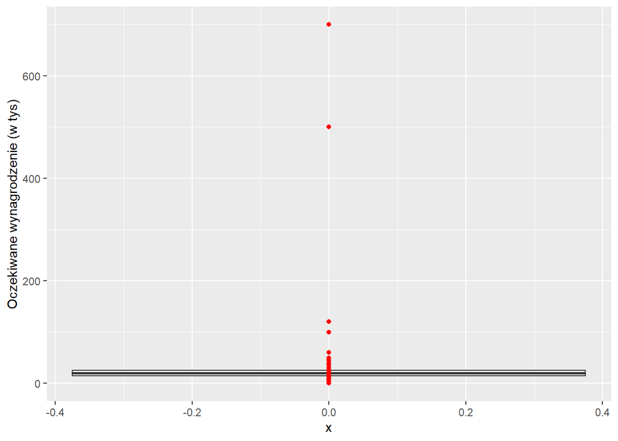

```r
dane1 %>%
  filter(OczekiwaneWynagrodzenie !=1500) %>%
  ggplot() +
  geom_boxplot(aes(y = OczekiwaneWynagrodzenie))+
  geom_point(aes(x=0, y=OczekiwaneWynagrodzenie), color="red")+
  labs(y="Oczekiwane wynagrodzenie (w tys)")
```

Nadal jest mało czytelnie. Generuję jeszcze raz, dla wartości poniżej 200 tys

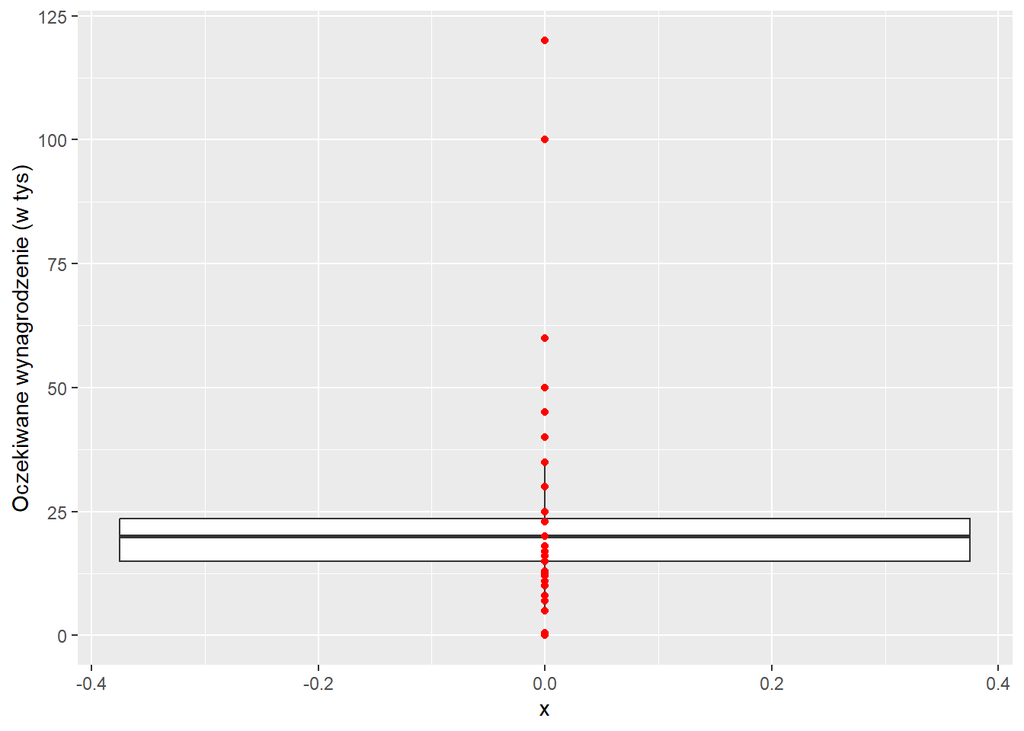

```r
dane1 %>%
  filter(OczekiwaneWynagrodzenie <200) %>%
  ggplot() +
  geom_boxplot(aes(y = OczekiwaneWynagrodzenie))+
  geom_point(aes(x=0, y=OczekiwaneWynagrodzenie), color="red")+
  labs(y="Oczekiwane wynagrodzenie (w tys)")
```

Ten wykres jest wreszcie czytelny. Pamiętam jednak, że tamte wartości nadal są, tylko pomijam je na tym wykresie.

### 13. Zmienna *‘CzyLubiszSwojDyplom’*:

Zmienna mówiąca o tym, czy student lubi swój dyplom, czy jest z niego zadowolony. Przyjmuje wartości ‘Yes’ lub ‘No’. Jest to zmienna typu *character*, którą także zamieniam na *factor*, a następnie za pomocą funkcji *table()* patrzę ile jest poszczególnych wartości

```r
dane$CzyLubiszSwojDyplom <- as.factor(dane$CzyLubiszSwojDyplom)

table(dane$CzyLubiszSwojDyplom)
```

```
##
##  No Yes
##  20 215
```

### 14. Zmienna *‘DalszaKariera’*:

Zmienna określająca chęć, gotowość studenta do kontynuowania kariery zawodowej związanej z posiadanym wykształceniem, wyrażona w procentach; do wybory opcje:

- 0%
- 25%
- 50%
- 75%
- 100%

Jest to zmienna typu *character*, którą także zamieniam na typ *factor* oraz nadaję kolejność poszczególnym kategoriom, gdyż powinna to być zmienna kategoryczna, bo mamy kolejne poziomy.  
Za pomocą funkcji *table()* sprawdzam ile studentów ma poszczególne poziomy chęci do kontynuowania kariery zawodowej, związanej z posiadanym wykształceniem. Dodatkowo przedstawiam te dane na wykresie kolumnowym

```r
dane$DalszaKariera <- as.factor(dane$DalszaKariera)

dane$DalszaKariera <- factor(dane$DalszaKariera, levels=c("0%", "25%", "50%", "75%", "100%"))

table(dane$DalszaKariera)
```

```
##
##   0%  25%  50%  75% 100%
##    2   14   61  114   44
```

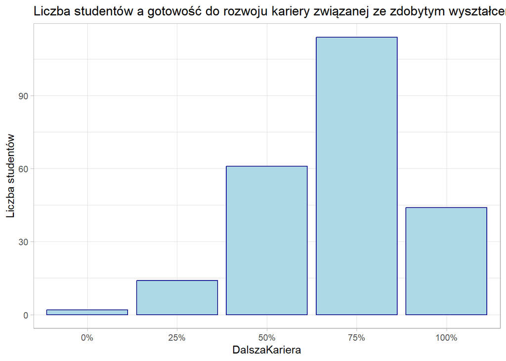

```r
dane %>%
  ggplot() +
  geom_bar(aes(x = DalszaKariera),
           position="dodge2",
           color = "darkblue", fill = "lightblue") +
  theme_light() +
  labs(title = "Liczba studentów a gotowość do rozwoju kariery związanej ze zdobytym wyształceniem",
       x = "DalszaKariera",
       y="Liczba studentów")
```

### 15. Zmienna *‘SocialMedia’*:

Zmienna opisująca czas spędzony przez studenta dziennie na social mediach lub oglądaniu video.  
Możliwe przedziały:

Jest to zmienna typu *character*, ale ponownie zamieniam ją na *factor*. Podobnie jak przy zmiennej CzasNauki powinna to być zmienna kategoryczna, bo mamy kolejne poziomy czasu spędzonego na social mediach, dlatego nadaję kolejność poszczególnym kategoriom, zmieniając od razu nazwy przedziałów na krótsze, logiczne, poprawne gramatycznie, ujednolicone  
Za pomocą funkcji *table()* sprawdzam ile studentów spędza określony czas na social mediach i oglądaniu video. Dodatkowo przedstawiam te dane na wykresie kolumnowym

```r
dane$SocialMedia <- as.factor(dane$SocialMedia)

dane$SocialMedia <- factor(dane$SocialMedia, levels=c("0 Minute", "1 - 30 Minute", "30 - 60 Minute", "1 - 1.30 hour", "1.30 - 2 hour", "More than 2 hour"), labels = c("0h", "0-0.5h", "0.5-1h", "1-1.5h", "1.5-2h", ">2h"))

table(dane$SocialMedia)
```

```
##
##     0h 0-0.5h 0.5-1h 1-1.5h 1.5-2h    >2h
##      5     47     69     55     27     32
```

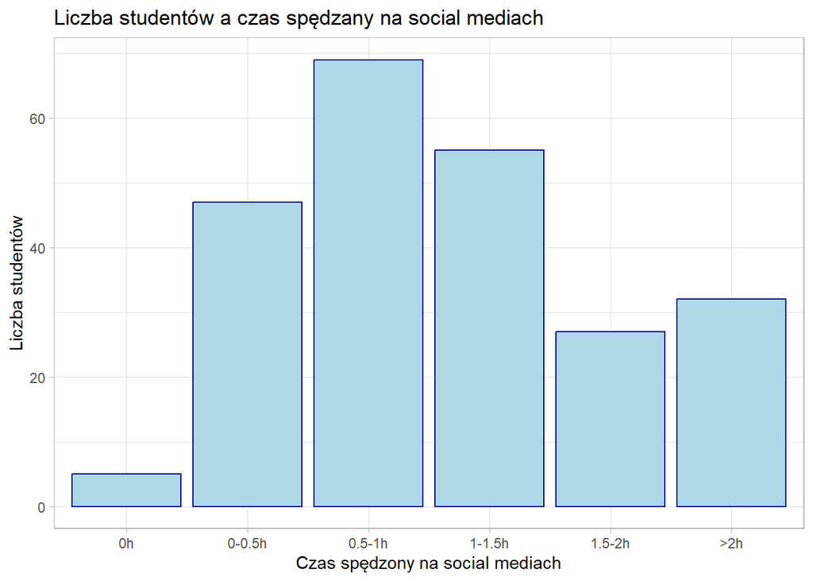

```r
dane %>%
  ggplot() +
  geom_bar(aes(x = SocialMedia),
           position = "dodge2",
           color = "darkblue", fill = "lightblue") +
  theme_light() +
  labs(title = "Liczba studentów a czas spędzany na social mediach",
       x = "Czas spędzony na social mediach",
       y="Liczba studentów")
```

### 16. Zmienna *‘CzasDojazdu’*:

Zmienna opisująca czas spędzony przez studenta dziennie na dojazd do placówki edukacyjnej.  
Możliwe przedziały:

Tak jak poprzednio, jest to zmienna typu *character*, ale zamieniam ją na *factor*, nadaję kolejność poszczególnym kategoriom, zmieniając nazwy przedziałów.  
Za pomocą funkcji *table()* sprawdzam ile studentów spędza określony czas na dojazdach na uczelnię. Dodatkowo przedstawiam te dane na wykresie kolumnowym

```r
dane$CzasDojazdu <- as.factor(dane$CzasDojazdu)

dane$CzasDojazdu <- factor(dane$CzasDojazdu, levels=c("0 - 30 minutes", "30 - 60 minutes", "1 - 1.30 hour", "1.30 - 2 hour", "2 - 2.30 hour", "2.30 - 3 hour", "more than 3 hour"), labels = c("0-0.5h", "0.5-1h", "1-1.5h", "1.5-2h", "2-2.5h", "2.5-3h", ">3h"))

table(dane$CzasDojazdu)
```

```
##
## 0-0.5h 0.5-1h 1-1.5h 1.5-2h 2-2.5h 2.5-3h    >3h
##     55     80     51     18     14      7     10
```

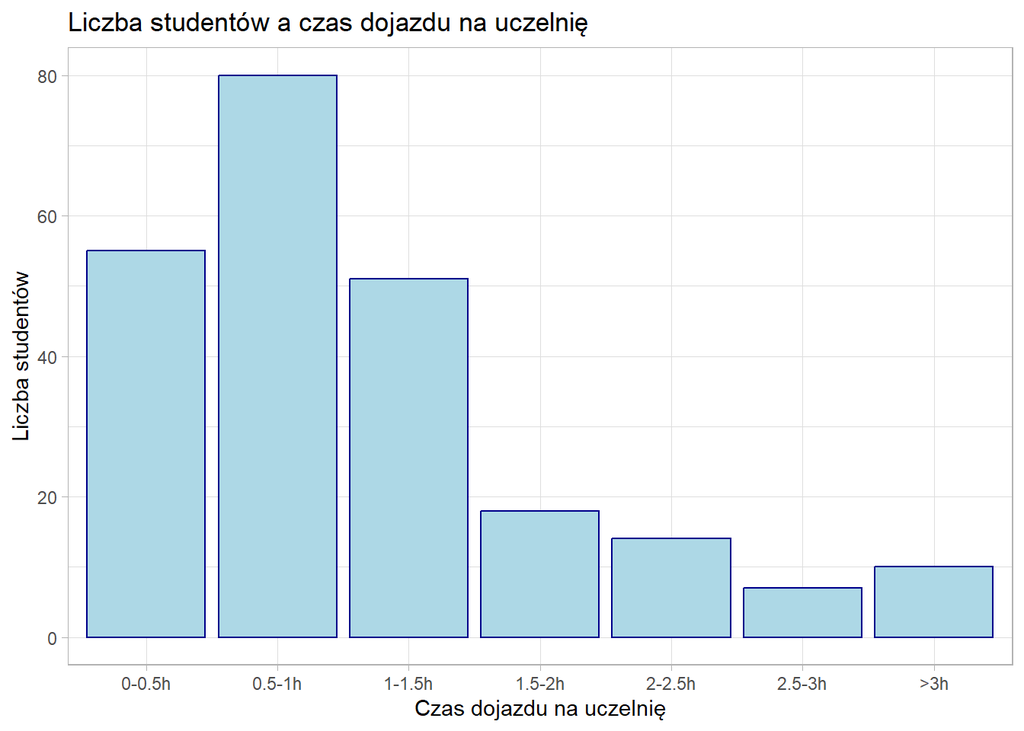

```r
dane %>%
  ggplot() +
  geom_bar(aes(x = CzasDojazdu),
           position="dodge2",
           color = "darkblue", fill = "lightblue") +
  theme_light() +
  labs(title = "Liczba studentów a czas dojazdu na uczelnię",
       x = "Czas dojazdu na uczelnię",
       y="Liczba studentów")
```

### 17. Zmienna *‘Stres’*:

Zmienna opisująca poziom stresu studenta.  
Możliwe opcje:

- fabulous
- Good
- Bad
- Awful

Jest to zmienna typu *character*, zmieniam typ na *factor*, nadaje kolejność i zmieniam nazwy, aby fabulous także było z wielkiej litery.  
Za pomocą funkcji *table()* sprawdzam ile studentów odczuwa poszczególny poziom stresu. Dodatkowo przedstawiam te dane na wykresie kolumnowym

```r
dane$Stres <- as.factor(dane$Stres)

dane$Stres <- factor(dane$Stres, levels=c("Awful", "Bad", "Good", "fabulous"), labels = c("Awful", "Bad", "Good", "Fabulous"))

table(dane$Stres)
```

```
##
##    Awful      Bad     Good Fabulous
##       19       68      137       11
```

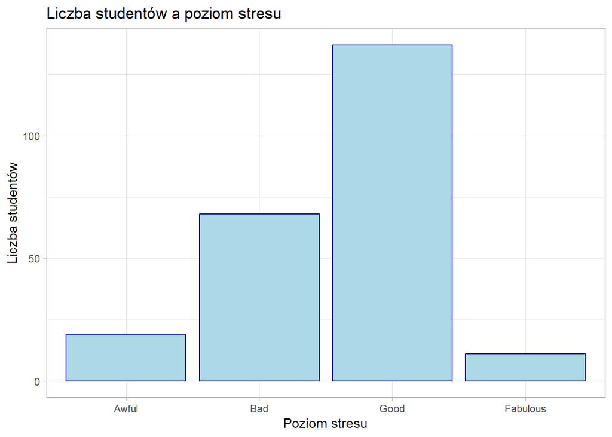

```r
dane %>%
  ggplot() +
  geom_bar(aes(x = Stres),
           position="dodge2",
           color = "darkblue", fill = "lightblue") +
  theme_light() +
  labs(title = "Liczba studentów a poziom stresu",
       x = "Poziom stresu",
       y="Liczba studentów")
```

### 18. Zmienna *‘StatusFinansowy’*:

Zmienna opisująca poziom sytuacji finansowej, ekonomicznej studenta.  
Możliwe opcje:

- Fabulous
- good
- Bad
- Awful

Jest to zmienna typu *character*, zmieniam typ na *factor*, nadaje kolejność i zmieniam nazwy, aby good także było z wielkiej litery.  
Za pomocą funkcji *table()* sprawdzam ile studentów ma poszczególny poziom sytuacji finansowej. Dodatkowo przedstawiam te dane na wykresie kolumnowym

```r
dane$StatusFinansowy <- as.factor(dane$StatusFinansowy)

dane$StatusFinansowy <- factor(dane$StatusFinansowy, levels=c("Awful", "Bad", "good", "Fabulous"), labels = c("Awful", "Bad", "Good", "Fabulous"))

table(dane$StatusFinansowy)
```

```
##
##    Awful      Bad     Good Fabulous
##       14       88      129        4
```

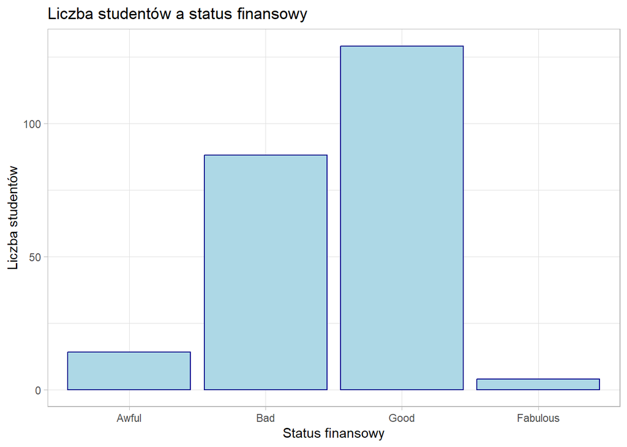

```r
dane %>%
  ggplot() +
  geom_bar(aes(x = StatusFinansowy),
           position="dodge2",
           color = "darkblue", fill = "lightblue") +
  theme_light() +
  labs(title = "Liczba studentów a status finansowy",
       x = "Status finansowy",
       y="Liczba studentów")
```

### 19. Zmienna *‘Praca’*:

Zmienna informująca o tym, czy student pracuje w niepełnym wymiarze godzin. Jest to zmienna typu character, która przyjmuje wartości ‘Yes’ lub ‘No’. Zmieniam typ na *factor*, a następnie za pomocą funkcji *table()* patrzę ile jest poszczególnych wartości

```r
dane$Praca <- as.factor(dane$Praca)

table(dane$Praca)
```

```
##
##  No Yes
## 194  41
```

Zdecydowana większość, bo aż 194 studentów nie pracuje.

## BADANIE ZMIENNYCH ILOŚCIOWYCH

Zmienne ilościowe w analizowanym zestawie danych to: *Wzrost*, *Waga*, *Ocena10*, *Ocena12*, *OcenaUczelnia* oraz *OczekiwaneWynagrodzenie*.

Wyznaczam szczegółowe statystyki opisowe zmiennych ilościowych, za pomocą funkcji *describe()* z pakietu *psych()*

```r
dane %>%
  select(Wzrost, Waga, Ocena10, Ocena12, OcenaUczelnia, OczekiwaneWynagrodzenie) %>%
  describe()
```

```
##                         vars   n     mean        sd median  trimmed     mad
## Wzrost                     1 235   157.40     21.51    160   160.42   14.83
## Waga                       2 235    60.80     14.90     60    60.35   14.83
## Ocena10                    3 235    76.84     13.05     80    77.99   13.34
## Ocena12                    4 235    68.78     11.02     69    68.73   13.34
## OcenaUczelnia              5 235    70.66     15.73     70    72.09   14.83
## OczekiwaneWynagrodzenie    6 235 32481.68 111314.63  20000 19193.12 7413.00
##                          min     max     range  skew kurtosis      se
## Wzrost                   4.5     192     187.5 -2.55    11.60    1.40
## Waga                    20.0     106      86.0  0.25    -0.39    0.97
## Ocena10                  7.4      98      90.6 -1.13     2.51    0.85
## Ocena12                 45.0      94      49.0  0.07    -0.67    0.72
## OcenaUczelnia            1.0     100      99.0 -1.61     4.78    1.03
## OczekiwaneWynagrodzenie  0.0 1500000 1500000.0 10.99   132.38 7261.37
```

Badam powiązania między zmiennymi ilościowymi, czyli Wzrost, Waga, Ocena10, Ocena12, OcenaUczelnia oraz OczekiwaneWynagrodzenie. W tym celu wyznaczamy współczynnik korelacji rangowej Spearmana oraz przedstawiam macierz korelacji za pomocą wizualizacji

```r
cor = cor(dane[,c("Wzrost", "Waga", "Ocena10",
                      "Ocena12", "OcenaUczelnia", "OczekiwaneWynagrodzenie")],
          method = "spearman")
round(cor, 2)
```

```
##                         Wzrost  Waga Ocena10 Ocena12 OcenaUczelnia
## Wzrost                    1.00  0.42    0.07   -0.10          0.02
## Waga                      0.42  1.00    0.05   -0.04         -0.04
## Ocena10                   0.07  0.05    1.00    0.48          0.56
## Ocena12                  -0.10 -0.04    0.48    1.00          0.51
## OcenaUczelnia             0.02 -0.04    0.56    0.51          1.00
## OczekiwaneWynagrodzenie   0.06  0.15    0.00   -0.13          0.05
##                         OczekiwaneWynagrodzenie
## Wzrost                                     0.06
## Waga                                       0.15
## Ocena10                                    0.00
## Ocena12                                   -0.13
## OcenaUczelnia                              0.05
## OczekiwaneWynagrodzenie                    1.00
```

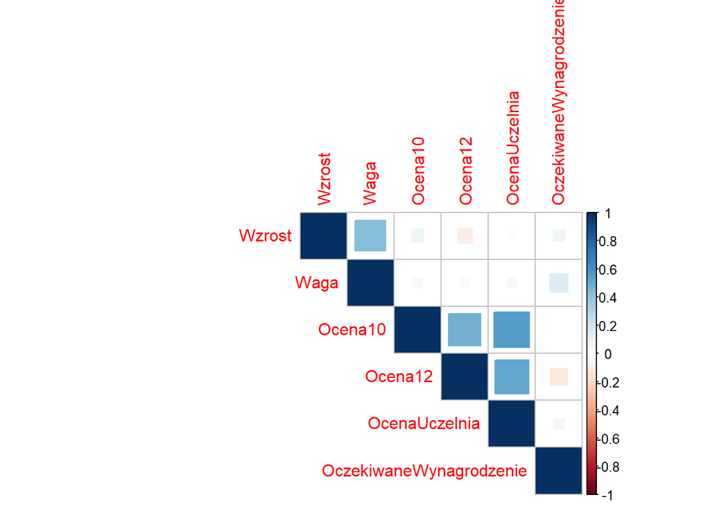

```r
corrplot(cor, method = "square", type = "upper")
```

**WNIOSKI**  
- Wzrost i waga nie są liniowo związane z ocenami.  
- Wzrost jest dość związany z wagą, co jest naturalnym zjawiskiem.  
- Poszczególne oceny (w 10 klasie, w 12 klasie i na uczelni) także są liniowo związane.  
- Największa zależność jest pomiędzy oceną z klasy 10 i oceną na uczelni, a nie, jakby się mogło wydawać pomiędzy oceną z klasy 10 i 12 lub klasy 12 i uczelni.  
- Oczekiwane wynagrodzenie nie jest związane z żadną inną zmienną: nie zależy od ocen, ani od wzorstu i wagi

## **HIPOTEZY BADAWCZE**

### 1. Czy ukończenie kursu certyfikacyjnego ma wpływ na oceny studenta na uczelni? Co wpływa na oceny studentów na uczelni.

**UKOŃCZENIE KURSU CERTYFIKUJĄCEGO**  
Podejrzewam, że ukończenie kursu certyfikacyjnego przez studentów może mieć pozytywny wpływ na ocenę na uczelni. Student, który decyduje się na taki kurs jest z reguły bardziej ambitny, chce czegoś więcej, dlatego także i jego oceny powinny być wyższe.  
Próbuję potwierdzić tę hipotezę obliczając podstawowe statystyki opisowe (średnią, medianę i odchylenie standardowe), grupując studentów według ukończenia kursu.

```r
dane %>%
  group_by(Certyfikat) %>%
  summarise(srednia = mean(OcenaUczelnia),
            mediana = median(OcenaUczelnia),
            odch.st = sd(OcenaUczelnia))
```

```
## # A tibble: 2 × 4
##   Certyfikat srednia mediana odch.st
##   <fct>        <dbl>   <dbl>   <dbl>
## 1 No            66.4      70    16.7
## 2 Yes           73.0      75    14.7
```

Zarówno średnia, jak i mediana są wyższe w przypadku studentów, którzy ukończyli kurs certyfikacyjny, co potwierdza moje przypuszczenia.

Potwierdzę to, przedstawiając dodatkowo dane na wykresie krzywej gęstości

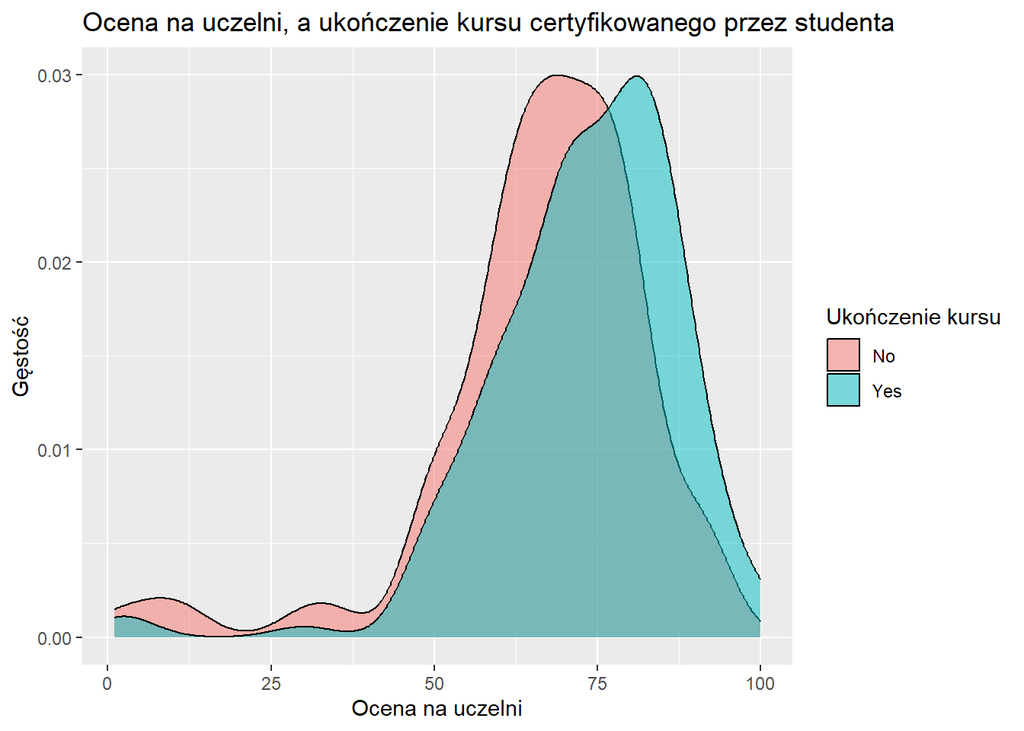

```r
dane %>%
  ggplot() +
  geom_density(aes(x = OcenaUczelnia,
                   fill = Certyfikat), alpha = 0.5)+
  labs(title="Ocena na uczelni, a ukończenie kursu certyfikowanego przez studenta",
       x="Ocena na uczelni",
       y="Gęstość",
       fill="Ukończenie kursu")
```

Tutaj również widać, że studenci, którzy ukończyli kurs certyfikacyjny uzyskują wyższe oceny na uczelni.

**PŁEĆ**  
Na podstawie mojego doświadczenia podejrzewam, że lepsze oceny będą wśród kobiet. Badam to za pomocą statystyk opisowych i krzywej gęstości.

```r
dane %>%
  group_by(Plec) %>%
  summarise(srednia = mean(OcenaUczelnia),
            mediana = median(OcenaUczelnia),
            odch.st = sd(OcenaUczelnia))
```

```
## # A tibble: 2 × 4
##   Plec   srednia mediana odch.st
##   <fct>    <dbl>   <dbl>   <dbl>
## 1 Female    76.9      80    13.2
## 2 Male      67.5      70    16.0
```

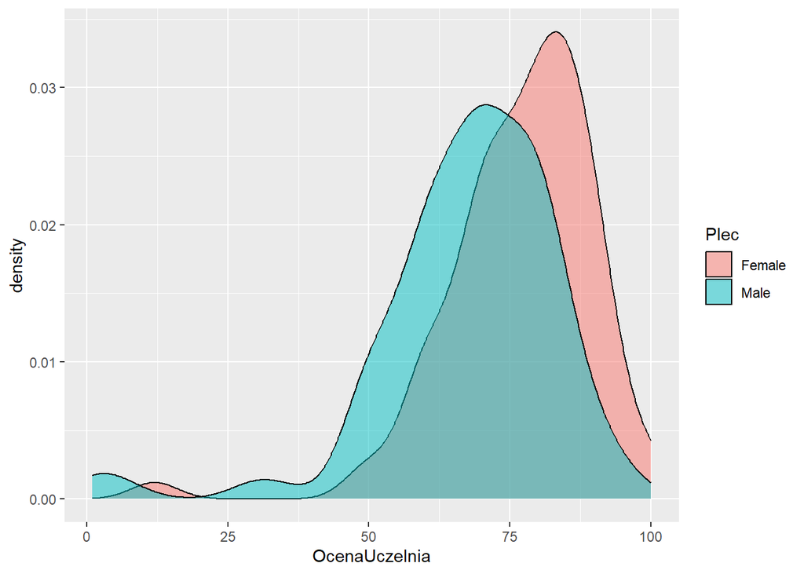

```r
dane %>%
  ggplot() +
  geom_density(aes(x = OcenaUczelnia,
                   fill = Plec), alpha = 0.5)
```

Krzywa gęstości także potwierdza przypuszczenie o wyższych wynikach wśród kobiet niż wśród mężczyzn.

**CZAS NAUKI**

```r
dane %>%
  group_by(CzasNauki) %>%
  summarise(srednia = mean(OcenaUczelnia),
            mediana = median(OcenaUczelnia),
            odch.st = sd(OcenaUczelnia))
```

```
## # A tibble: 6 × 4
##   CzasNauki srednia mediana odch.st
##   <fct>       <dbl>   <dbl>   <dbl>
## 1 0-0.5h       68.7    70      15.8
## 2 0.5-1h       69.9    70      12.3
## 3 1-2h         70.3    70      19.1
## 4 2-3h         75.9    78      10.0
## 5 3-4h         75.5    80      18.4
## 6 >4h          67.8    72.5    24.4
```

Rzeczywiście im dłuższy czas nauki, tym średnia ocen jest wyższa, jednak przy ponad 4 godzinach nauki średnia drastycznie spada i jest nawet mniejsza niż przy mniej niż pół godzinie nauki. Działa więc powiedzenie “Co za dużo, to niezdrowo”, czyli dużo nauki jest dobre, ale nie można przesadzać, gdyż może to prowadzić do odwrotnych skutków.

**SOCIAL MEDIA**

```r
dane %>%
  group_by(SocialMedia) %>%
  summarise(srednia = mean(OcenaUczelnia),
            mediana = median(OcenaUczelnia),
            odch.st = sd(OcenaUczelnia))
```

```
## # A tibble: 6 × 4
##   SocialMedia srednia mediana odch.st
##   <fct>         <dbl>   <dbl>   <dbl>
## 1 0h             72.4      68    11.8
## 2 0-0.5h         67.9      69    17.2
## 3 0.5-1h         71.9      75    13.7
## 4 1-1.5h         71.1      70    17.8
## 5 1.5-2h         72.3      75    12.3
## 6 >2h            69.4      72    17.4
```

Nie ma wyraźnego związku między czasem spędzanym na social mediach i oglądaniu video a ocenami na uczelni.

**POZIOM STRESU**

```r
dane %>%
  group_by(Stres) %>%
  summarise(srednia = mean(OcenaUczelnia),
            mediana = median(OcenaUczelnia),
            odch.st = sd(OcenaUczelnia))
```

```
## # A tibble: 4 × 4
##   Stres    srednia mediana odch.st
##   <fct>      <dbl>   <dbl>   <dbl>
## 1 Awful       70.3      70    13.7
## 2 Bad         68.8      70    11.6
## 3 Good        71.5      75    17.7
## 4 Fabulous    72.2      75    16.2
```

Poziomy stresu *‘Good’* i *‘Fabulous’* mają większe średnie ocen niż poziomy *‘Awful’* i *‘Bad’*, zatem możemy wnioskować, że studenci, którzy mają lepszy (to znaczy mniejszy) poziom stresu, osiągają lepsze wyniki w nauce.

**STATUS FINANSOWY**

```r
dane %>%
  group_by(StatusFinansowy) %>%
  summarise(srednia = mean(OcenaUczelnia),
            mediana = median(OcenaUczelnia),
            odch.st = sd(OcenaUczelnia))
```

```
## # A tibble: 4 × 4
##   StatusFinansowy srednia mediana odch.st
##   <fct>             <dbl>   <dbl>   <dbl>
## 1 Awful              69.6    75      15.6
## 2 Bad                69.8    70      13.6
## 3 Good               71.4    75      17.2
## 4 Fabulous           69      67.5    17.0
```

**CZAS DOJAZDU**

```r
dane %>%
  group_by(CzasDojazdu) %>%
  summarise(srednia = mean(OcenaUczelnia),
            mediana = median(OcenaUczelnia),
            odch.st = sd(OcenaUczelnia))
```

```
## # A tibble: 7 × 4
##   CzasDojazdu srednia mediana odch.st
##   <fct>         <dbl>   <dbl>   <dbl>
## 1 0-0.5h         73.3    70     12.7
## 2 0.5-1h         71.7    74.5   16.5
## 3 1-1.5h         65.4    67     19.3
## 4 1.5-2h         70.8    75     13.4
## 5 2-2.5h         73.8    80     11.4
## 6 2.5-3h         69.3    70      8.86
## 7 >3h            71      75     13.5
```

Czas dojazdu także nie ma większego związku z wysokością ocen

**PRACA**

```r
dane %>%
  group_by(Praca) %>%
  summarise(srednia = mean(OcenaUczelnia),
            mediana = median(OcenaUczelnia),
            odch.st = sd(OcenaUczelnia))
```

```
## # A tibble: 2 × 4
##   Praca srednia mediana odch.st
##   <fct>   <dbl>   <dbl>   <dbl>
## 1 No       70.4    73.6    16.2
## 2 Yes      72.1    70      13.6
```

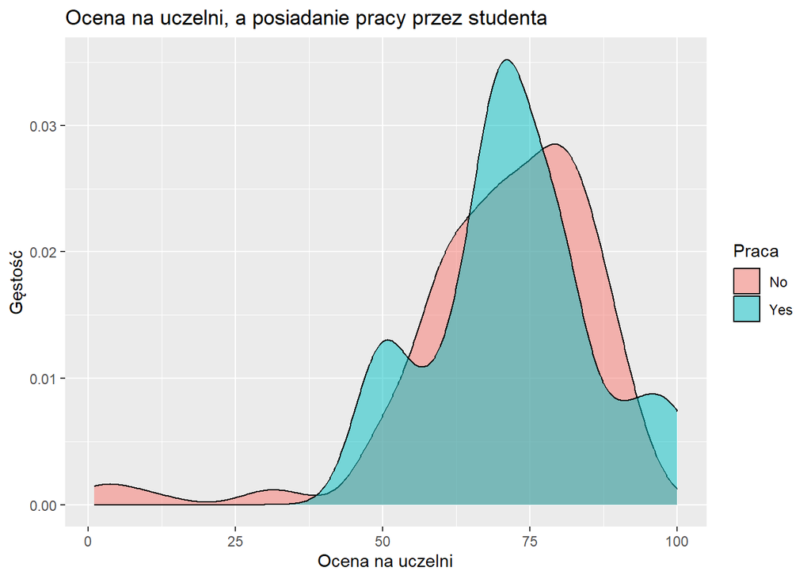

```r
dane %>%
  ggplot() +
  geom_density(aes(x = OcenaUczelnia,
                   fill = Praca), alpha = 0.5)+
  labs(title="Ocena na uczelni, a posiadanie pracy przez studenta",
       x="Ocena na uczelni",
       y="Gęstość",
       fill="Praca")
```

Tutuaj także nie widać jakichś specjalnych zależności posiadania pracy od wysokości oceny

### 2. Jak mają się do siebie oceny z klasy 10, z klasy 12 i z uczelni?

Przypuszczam, że najlepsze oceny będą w klasie 10, gdyż z reguły we wcześniejszych latach nauki łatwiej jest zdobyć dobre oceny. Myślę też, że zależności między ocenami będą dość duże, gdyż zazwyczaj na przestrzeni kilku lat oceny poszczególnych studentów nie ulegają drastycznym zmianom. Jedni mogą osiągać coraz lepsze wyniki, inni coraz gorsze, ale nadal będą to oceny na podobnym poziomie.

Sprawdzam rozkłady poszczególnych ocen za pomocą nałożenia na siebie trzech krzywych gęstości

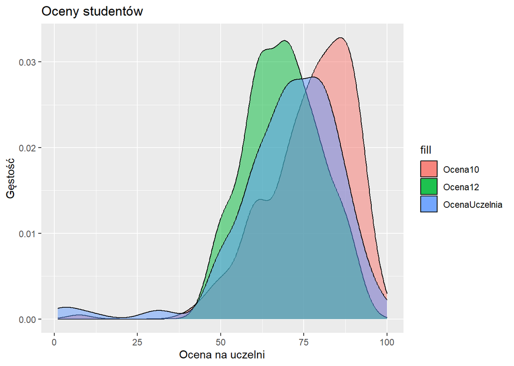

```r
dane %>%
  ggplot() +
  geom_density(aes(x = Ocena10, fill="Ocena10"), alpha = 0.5)+
  geom_density(aes(x = Ocena12, fill="Ocena12"), alpha = 0.5)+
  geom_density(aes(x = OcenaUczelnia, fill="OcenaUczelnia"), alpha = 0.5)+
    labs(title = "Oceny studentów",
       x = "Ocena na uczelni",
       y = "Gęstość")
```

Z wykresu można wyczytać, że najwięcej najwyższych ocen studenci osiągali w klasie 10, najwięcej najniższych w klasie 12, a oceny na uczelni znalazły się pomiędzy ocenami z klasy 10 i 12.

Zbadam, między którymi dwoma ocenami istnieje największa, a między którymi najmniejsza zależność liniowa. W tym celu wyznaczę współczynnik korelacji Spearmana i przedstawię wizualizację macierzy korelacji.

```r
cor_spearman <- cor(dane[,c("Ocena10", "Ocena12", "OcenaUczelnia")],
          method = "spearman")
round(cor_spearman, 2)
```

```
##               Ocena10 Ocena12 OcenaUczelnia
## Ocena10          1.00    0.48          0.56
## Ocena12          0.48    1.00          0.51
## OcenaUczelnia    0.56    0.51          1.00
```

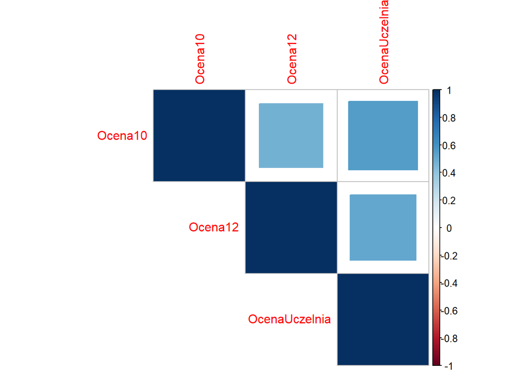

```r
corrplot(cor_spearman, method = "square", type = "upper")
```

Najciemniejszy, największy kwadrat jest na przecięciu zmiennych Ocena10 i OcenaUczelnia, czyli największa liniowa zależność jest między ocenami z klasy 10 i ocenami z uczelni, a nie jakby się bardziej wydawało między dwoma sąsiednimi (to znaczy ocenami z klasy 10 i 12 lub z klasy 12 i z uczelni).